# Min_Wen_Yang_scriptP2

1882252 Min Wen Yang

2022-09-22

```r
library(ggplot2)
library(GGally)
```

## Exercise 1

### 1.

```r
library(foreign)
spssdata <- read.spss("SPSSData.sav")
```

### 2.

```r
library("readxl")

importExceldata <- read_excel("ExcelData.xls")
```

## Exercise 2

### 1. Apparently the results are not equal. Can you explain this and how much is the difference? (hint: think about binary representation of integers and floating point numbers).

```r
sqrt(2) * sqrt(2) == 2
```

```
## [1] FALSE
```

This is because sqrt(2) is a floating point. So two floating points’ product is still a floating point. So that’s why sqrt(2) * sqrt(2) == 2 returns FALSE.

### 2. Find a solution for this problem. Hint: look at in-built functions round(), all.equal().

```r
round(sqrt(2) * sqrt(2), digits = 0) == 2
```

```
## [1] TRUE
```

```r
all.equal(sqrt(2) * sqrt(2), 2)
```

```
## [1] TRUE
```

solved.

### 3. Why is it important to be aware of this problem? Could you imagine a situation where you would need to take into account this issue?

During calculating via R, we have to be aware of floating point problem. Because This will give you wrong output.

## Exercise 3.

### 1.

```r
data(USArrests)
USArrests
```

### 2.

[,1] Murder numeric Murder arrests (per 100,000)  
[,2] Assault numeric Assault arrests (per 100,000)  
[,3] UrbanPop numeric Percent urban population  
[,4] Rape numeric Rape arrests (per 100,000)

### 3.

```r
summary(USArrests)
```

```
##      Murder          Assault         UrbanPop          Rape
##  Min.   : 0.800   Min.   : 45.0   Min.   :32.00   Min.   : 7.30
##  1st Qu.: 4.075   1st Qu.:109.0   1st Qu.:54.50   1st Qu.:15.07
##  Median : 7.250   Median :159.0   Median :66.00   Median :20.10
##  Mean   : 7.788   Mean   :170.8   Mean   :65.54   Mean   :21.23
##  3rd Qu.:11.250   3rd Qu.:249.0   3rd Qu.:77.75   3rd Qu.:26.18
##  Max.   :17.400   Max.   :337.0   Max.   :91.00   Max.   :46.00
```

it provides each variable’s minimum/maximum value, median, mean, 1st & 3rd quantile.

### 4.

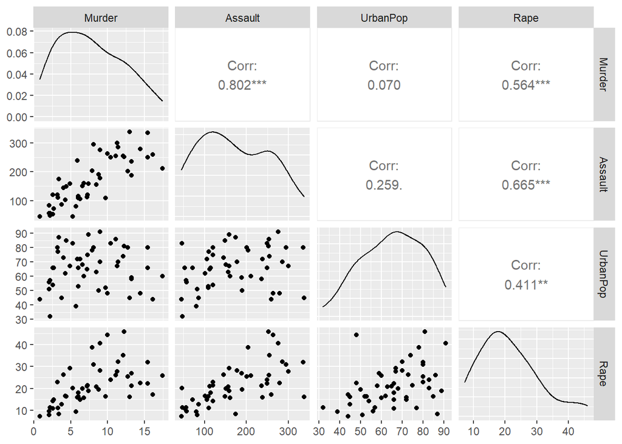

```r
ggpairs(USArrests)
```

It is clear that the correlation between “Assault” & “Murder” is the highest(0.802). There are some relation between “Rape”&“Murder”, “Rape”&“Assault” to some extent.

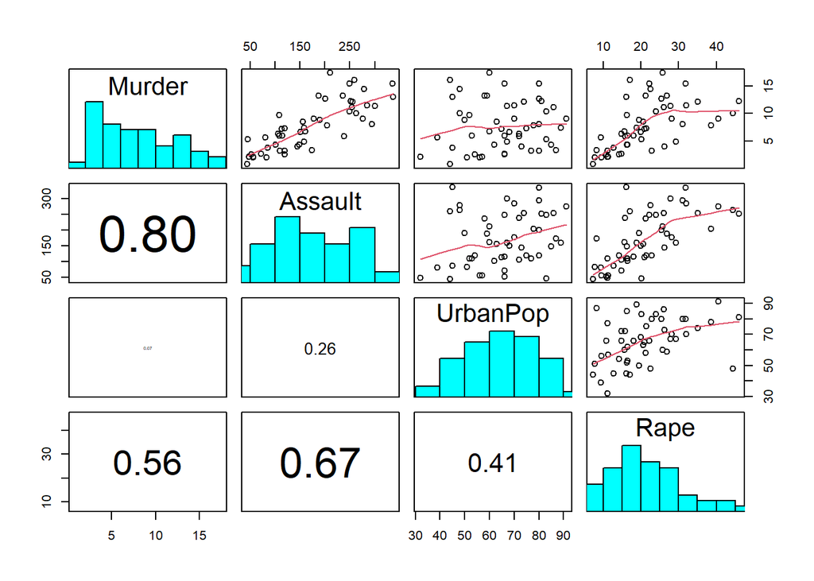

```r
panel.hist <- function(x, ...)
{
  usr <- par("usr")
  par(usr = c(usr[1:2], 0, 1.5) )
  h <- hist(x, plot = FALSE)
  breaks <- h$breaks; nB <- length(breaks)
  y <- h$counts; y <- y/max(y)
  rect(breaks[-nB], 0, breaks[-1], y, col = "cyan", ...)
}
panel.cor <- function(x, y, digits = 2, prefix = "", cex.cor, ...)
{
  par(usr = c(0, 1, 0, 1))
  r <- abs(cor(x, y))
  txt <- format(c(r, 0.123456789), digits = digits)[1]
  txt <- paste0(prefix, txt)
  if(missing(cex.cor)) cex.cor <- 0.8/strwidth(txt)
  text(0.5, 0.5, txt, cex = cex.cor * r)
}

pairs(USArrests, diag.panel = panel.hist, upper.panel = panel.smooth, lower.panel = panel.cor)
```

### 6.

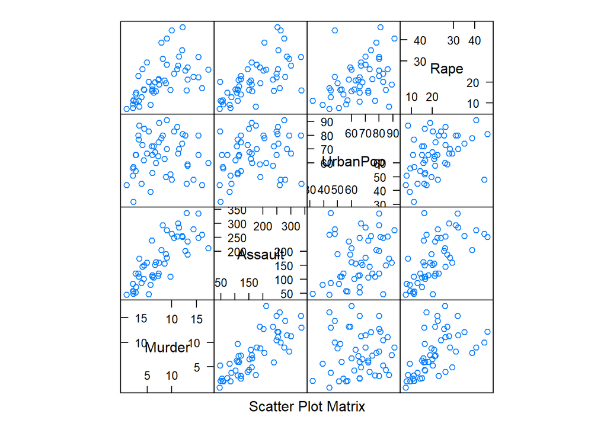

```r
library(lattice)

splom(~USArrests)
```

### 7.

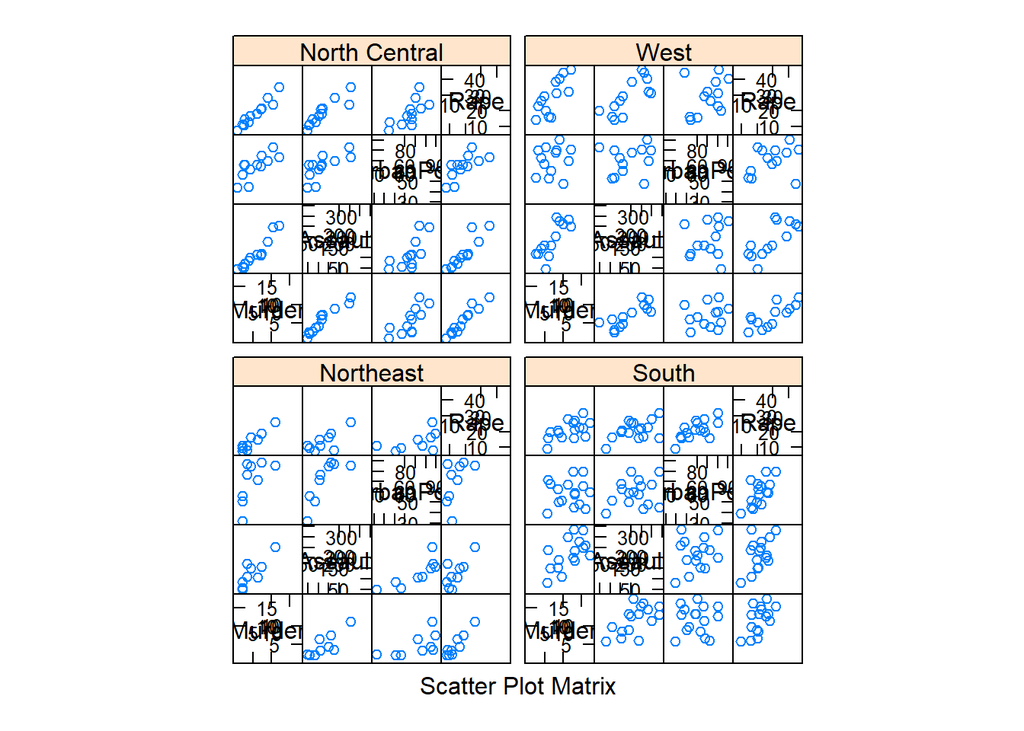

```r
splom(~USArrests | state.region)
```

## Exercise 4.

```r
load("ChildIQ.RData")
```

### 1.

```r
summary(ChildData)
```

```
##    kid.score         mom.hs           mom.iq          mom.work
##  Min.   : 20.0   Min.   :0.0000   Min.   : 71.04   Min.   :1.000
##  1st Qu.: 74.0   1st Qu.:1.0000   1st Qu.: 88.66   1st Qu.:2.000
##  Median : 90.0   Median :1.0000   Median : 97.92   Median :3.000
##  Mean   : 86.8   Mean   :0.7857   Mean   :100.00   Mean   :2.896
##  3rd Qu.:102.0   3rd Qu.:1.0000   3rd Qu.:110.27   3rd Qu.:4.000
##  Max.   :144.0   Max.   :1.0000   Max.   :138.89   Max.   :4.000
##     mom.age
##  Min.   :17.00
##  1st Qu.:21.00
##  Median :23.00
##  Mean   :22.79
##  3rd Qu.:25.00
##  Max.   :29.00
```

This shows the mean, median, minimum/maximum value, 1st & 3rd quantile of each variables.

```r
dim(ChildData)
```

```
## [1] 434   5
```

This shows the numbers of the observation and the number of the variable.

```r
str(ChildData)
```

```
## 'data.frame':    434 obs. of  5 variables:
##  $ kid.score: int  65 98 85 83 115 98 69 106 102 95 ...
##  $ mom.hs   : num  1 1 1 1 1 0 1 1 1 1 ...
##  $ mom.iq   : num  121.1 89.4 115.4 99.4 92.7 ...
##  $ mom.work : int  4 4 4 3 4 1 4 3 1 1 ...
##  $ mom.age  : int  27 25 27 25 27 18 20 23 24 19 ...
##  - attr(*, "datalabel")= chr "Written by R.              "
##  - attr(*, "time.stamp")= chr "10 May 2006 15:27"
##  - attr(*, "formats")= chr [1:5] "%9.0g" "%9.0g" "%9.0g" "%9.0g" ...
##  - attr(*, "types")= int [1:5] 253 255 255 253 253
##  - attr(*, "val.labels")= chr [1:5] "" "" "" "" ...
##  - attr(*, "var.labels")= chr [1:5] "kid.score" "mom.hs" "mom.iq" "mom.work" ...
##  - attr(*, "version")= int -8
##  - attr(*, "label.table")=List of 5
##   ..$ : NULL
##   ..$ : NULL
##   ..$ : NULL
##   ..$ : NULL
##   ..$ : NULL
```

This shows the structure of the data.

```r
head(ChildData)
```

```
##   kid.score mom.hs    mom.iq mom.work mom.age
## 1        65      1 121.11753        4      27
## 2        98      1  89.36188        4      25
## 3        85      1 115.44316        4      27
## 4        83      1  99.44964        3      25
## 5       115      1  92.74571        4      27
## 6        98      0 107.90184        1      18
```

This shows the top 6 observations of the data.

### 2.

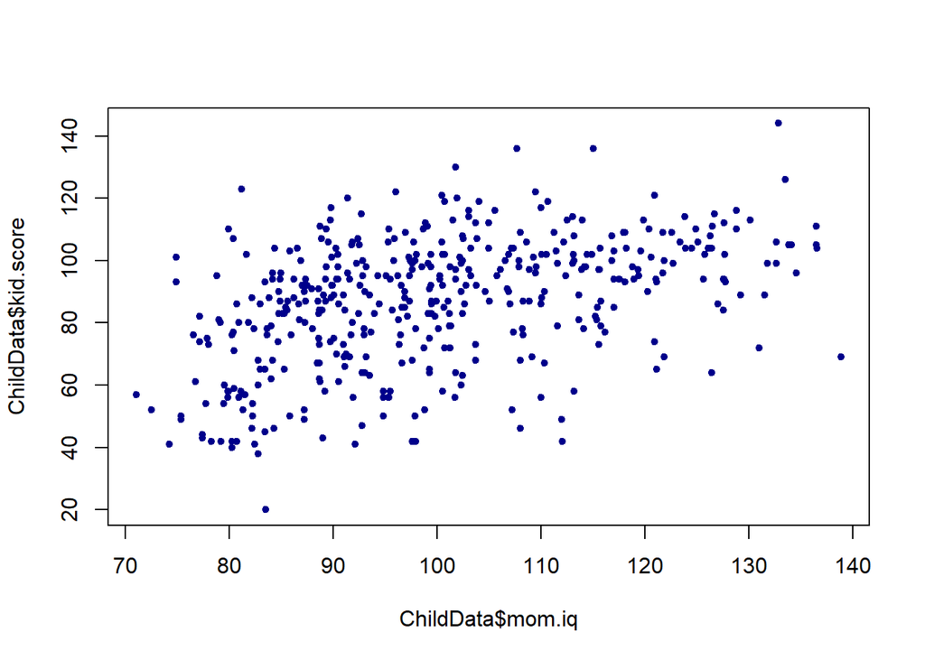

```r
plot(ChildData$mom.iq, ChildData$kid.score, pch = 20, col = "darkblue")
```

### 3.

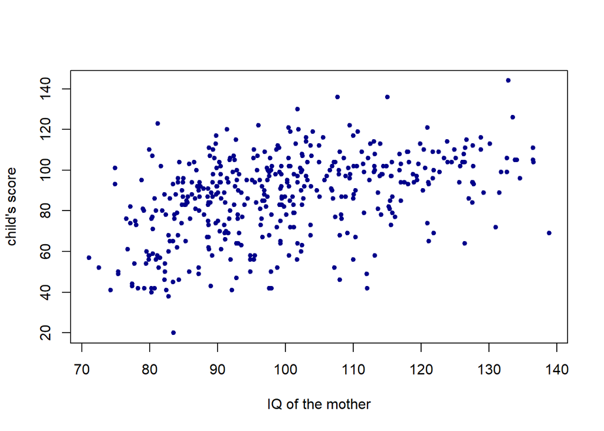

```r
plot(ChildData$mom.iq, ChildData$kid.score, pch = 20, col = "darkblue", xlab = "IQ of the mother", ylab = "child's score")
```

### 4.

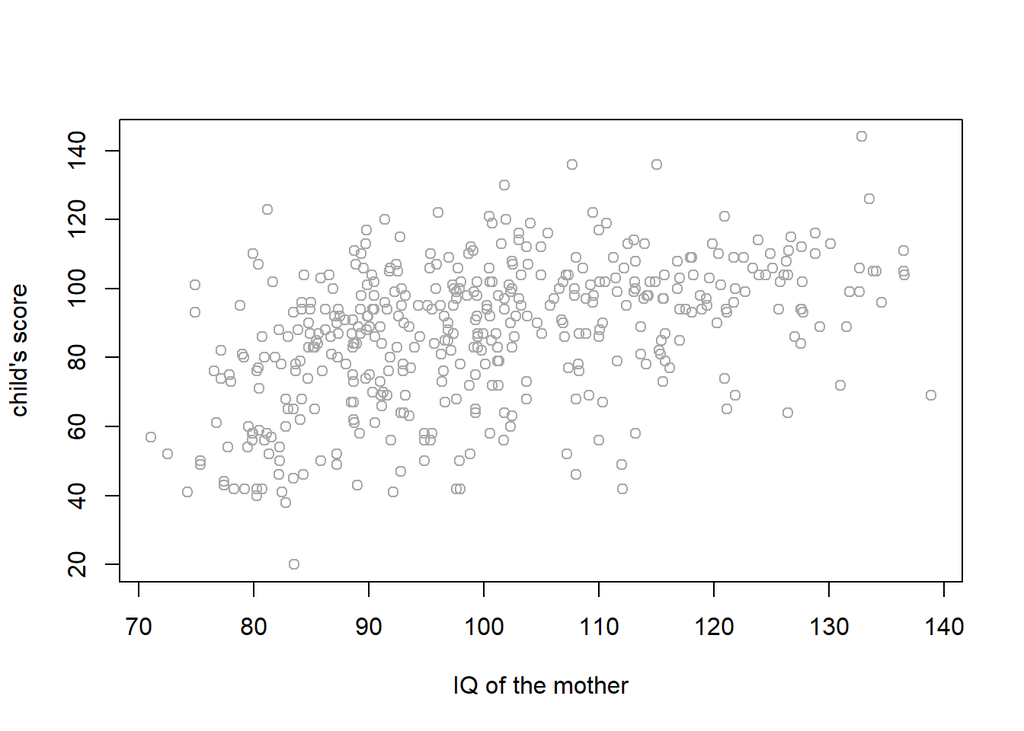

```r
plot(ChildData$mom.iq, ChildData$kid.score, pch = 1, col = "darkgrey", xlab = "IQ of the mother", ylab = "child's score")
```

### 5.

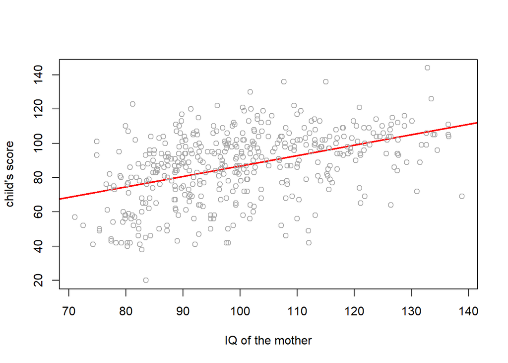

```r
plot(ChildData$mom.iq, ChildData$kid.score, pch = 1, col = "darkgrey", xlab = "IQ of the mother", ylab = "child's score",
     abline(lm(ChildData$kid.score~ChildData$mom.iq), lwd = 2, col = "red"))
```

### 6.

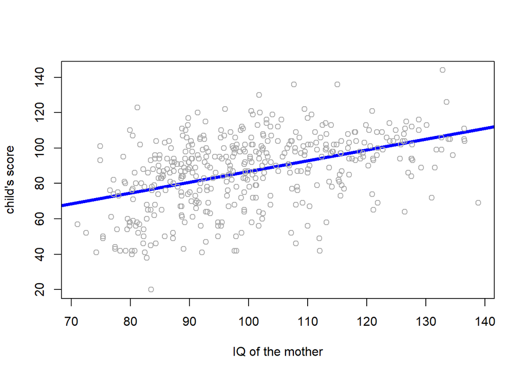

```r
plot(ChildData$mom.iq, ChildData$kid.score, pch = 1, col = "darkgrey", xlab = "IQ of the mother", ylab = "child's score",
     abline(lm(ChildData$kid.score~ChildData$mom.iq), lwd = 4, col = "blue"))
```